## Практична робота №5 . Закони розподілу та числові характеристики випадкових величин.

# Мета : набути практичних навичок у розв’язанні задач на знаходження законів розподілу та числових характеристик дискретних та неперервних випадкових величин, зокрема нормального закону, та розв’язання типових задач по цій темі.

# 1 . НВВ 𝑋 має експоненціальний розподіл з параметром 𝜆. Функція щільності експоненціального розподілу 𝑓(𝑥) = 𝜆𝑒−𝜆𝑥,𝑥 ≥ 0. Вивести формулу функції рівномірного розподілу 𝐹(𝑥), формулу для математичного сподівання M(𝑥), дисперсії 𝐷(𝑥), ймовірності події 𝛼 ≤ 𝑋 ≤ 𝑏.

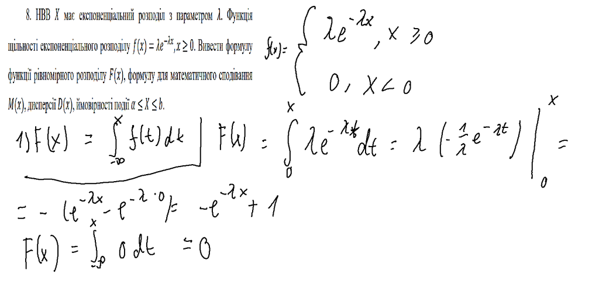

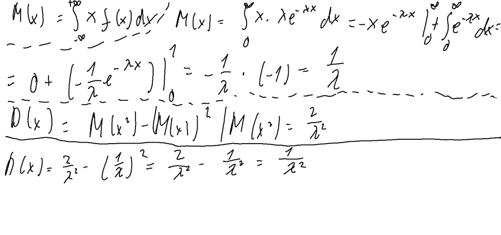

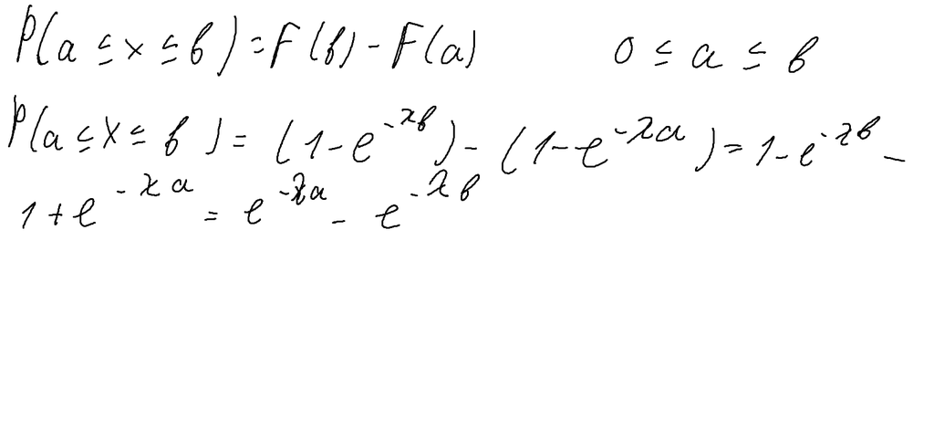

# 2 . НВВ 𝑋 має розподіл Коші. Функція щільності розподілу Коші задана у вигляді 𝑓(𝑥) = 𝑐/1+𝑥^2, де 𝑐 – деяка константа. Знайти константу 𝑐, функцію розподілу Коші 𝐹(𝑥) та ймовірність події −1 ≤ 𝑋 ≤ 1.

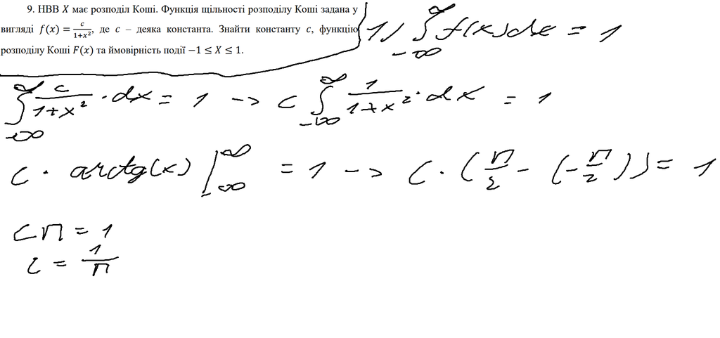

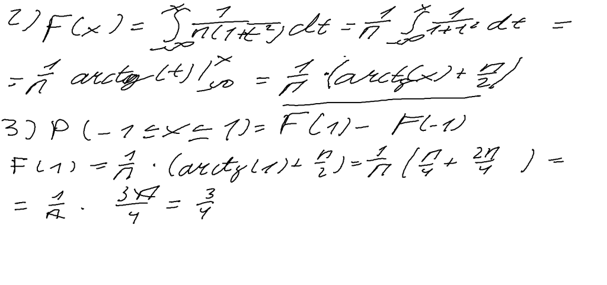

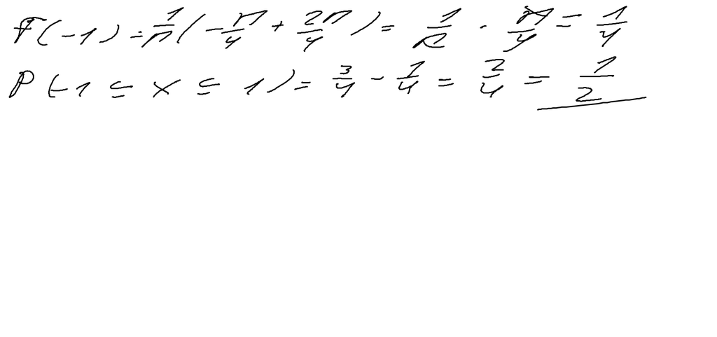